# Lista 1 de Administração Financeira II

#### Data: 02/11/2021

## Discente: Nadson Ângelo Silva Nogueira

## Docente: Anderson Luiz Rezende Mól

### Resumo

O presente trabalho tem como objetivo apresentar os resultados da Lista Complementar de Atividades da disciplina de Administração Financeira II, lecionada pelo Professor Anderson Luiz Rezende Mól, Dr.

## Respostas

### Questão 1)

### Com base na planilha “Dados_Ações” faça:

1. Calcule o retorno composto discreto do período jan/2018 a mar/2019 para as ações (VALE3, PETR4, BBDC4, KROT3, USIM5 e HGTX3);
2. Calcule o retorno composto continuo do período jan/2018 a mar/2019 para as ações (VALE3, PETR4, BBDC4, KROT3, USIM5 e HGTX3);

Os itens a) e b) foram respondidos logo abaixo:

```r
# Link para download do arquivo
url = "https://github.com/nadsu077/Adm_FinII/raw/main/Dados_A%C3%A7%C3%B5es.xlsx"
temp = tempfile() # Arquivo temporário
download.file(url, temp, quiet = T) # Fazendo o download do arquivo

df = as.data.frame(read_excel(temp)) # Lendo o arquivo usando o readxl
dates = seq(as.Date(df[1,2]), as.Date(df[nrow(df),2]), "month") # Criando a sequencia de datas, de 2018-01-01 a 2019-03-01, mês a mês

df.ts = ret.disc = ret.cont = list() # Criando as listas que irão receber os valores

# Loop para transformar cada ação em uma Série Temporal usando o as.timeSeries do pacote timeSeries e calculando o retorno de cada ativo usando a função CalculateReturns com o argumento "discrete" para retorno discreto e "log" para retorno contínuo.
for (i in 3:8){
  df.ts[[i-2]] = as.timeSeries(df[,i], dates, frequency = 12)
  ret.disc[[i-2]] = CalculateReturns(df.ts[[i-2]], method = "discrete")[-1,]
  ret.cont[[i-2]] = CalculateReturns(df.ts[[i-2]], method = "log")[-1,]
}

# Compatibilizando as listas em um data frame, transformando em série temporal e omitindo os NA
ret.cont = ret.cont %>% do.call(cbind, .) %>%
  as.timeSeries() %>% na.omit()

ret.disc = ret.disc %>% do.call(cbind, .) %>%
  as.timeSeries() %>% na.omit()
```

Abaixo seguem os gráficos do Retorno Composto Discreto e o Retorno Composto Contínuo, respectivamente.

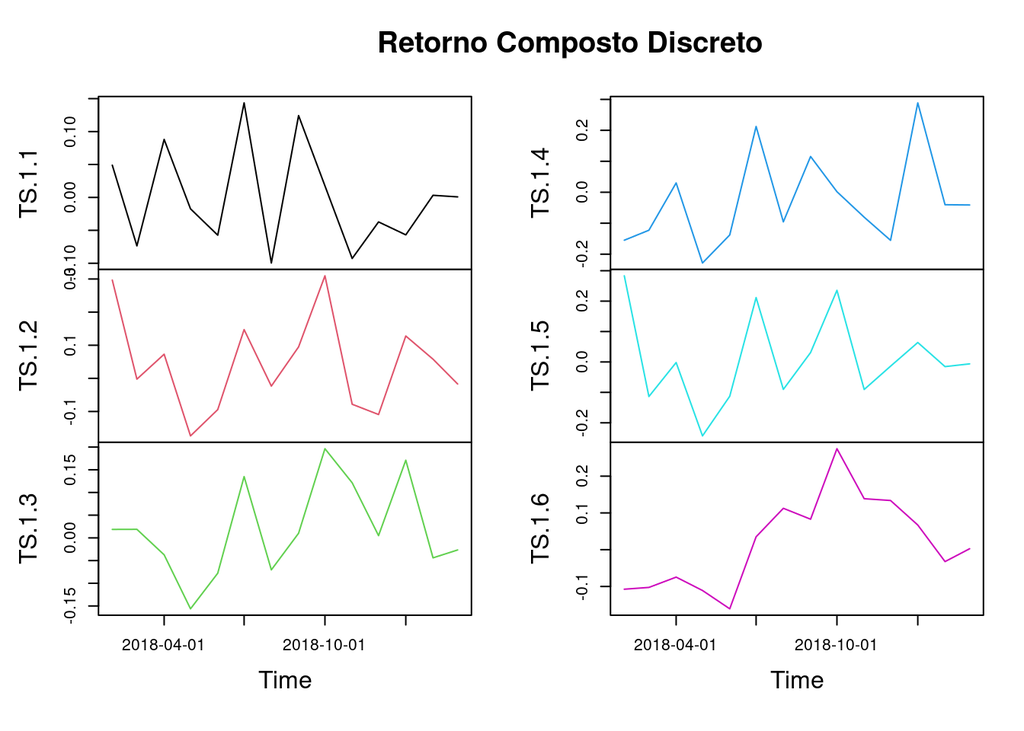

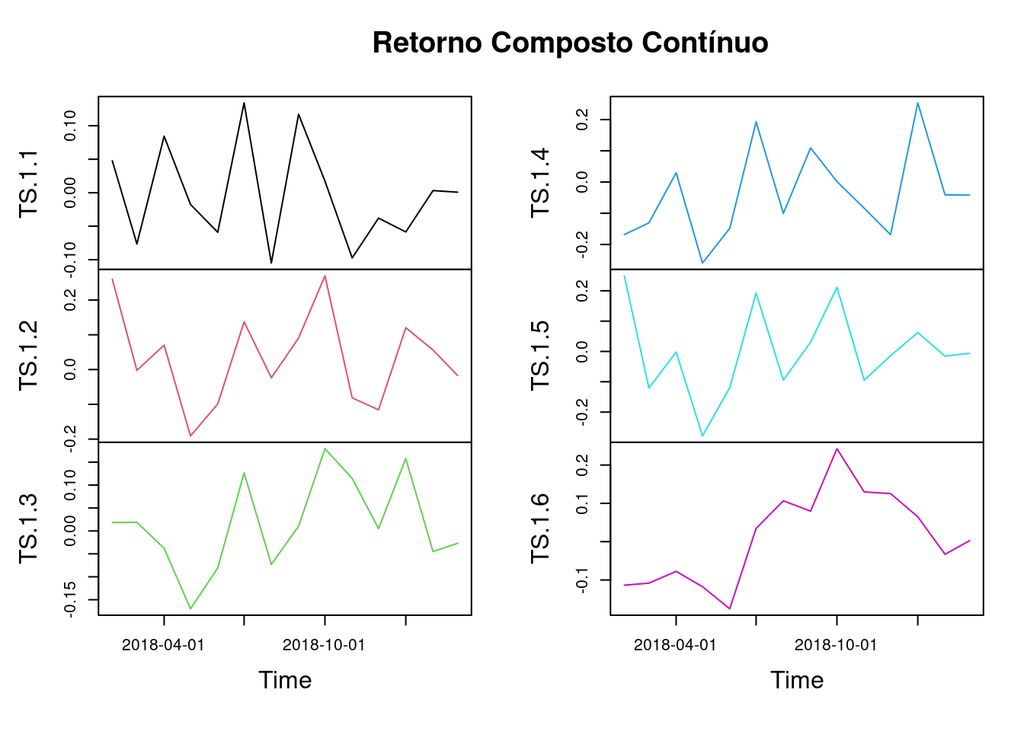

3. Calcule o risco para cada um dos ativos

```r
df.ts = df.ts %>% do.call(cbind, .) %>% as.data.frame()

df.ret.disc = ret.disc %>% as.data.frame()

df.ret.cont = ret.cont %>% as.data.frame()

stdev = list()
for (i in 1:ncol(df.ret.disc)){
  stdev[[i]] = data.frame(Risco_Disc_SD = sd(df.ret.disc[,i], na.rm = T),
                          Risco_Disc_VAR = var(df.ret.disc[,i], na.rm = T),
                          Risco_Cont_SD = sd(df.ret.cont[,i], na.rm = T),
                          Risco_Cont_VAR = var(df.ret.cont[,i], na.rm = T),
                          row.names = names(df)[i+2])
}
stdev = stdev %>% do.call(rbind, .) %>% t() %>% as.data.frame()
print(stdev)
```

```
##                      Vale3      Petr4       BBDC4      Krot3      Usim5
## Risco_Disc_SD  0.077770286 0.14439062 0.102292686 0.14780183 0.14827640
## Risco_Disc_VAR 0.006048217 0.02084865 0.010463794 0.02184538 0.02198589
## Risco_Cont_SD  0.076574884 0.13613635 0.099687464 0.14566862 0.14504464
## Risco_Cont_VAR 0.005863713 0.01853311 0.009937591 0.02121935 0.02103795
##                     HGTX3
## Risco_Disc_SD  0.12400204
## Risco_Disc_VAR 0.01537651
## Risco_Cont_SD  0.12060042
## Risco_Cont_VAR 0.01454446
```

4. Calcule o Beta de mercado para as ações (VALE3, PETR4, BBDC4, KROT3, USIM5 e HGTX3) por meio da análise de regressão linear simples;
5. O que pode dizer sobre os betas calculados?
6. Se tivesse que investir em apenas um ativo, qual deles recomendaria o investimento?

```r
# d)
lm.ativos = list()
i = 3
while (i < 9){
  mdl = lm(df[,i] ~ IBOV, data = df)
  lm.ativos[[i-2]] = summary(mdl)
  i = i+1
}
names(lm.ativos) <- paste0("LM.Ativo_",names(df[,3:8]))
lm.ativos
```

```
## $LM.Ativo_Vale3
##
## Call:
## lm(formula = df[, i] ~ IBOV, data = df)
##
## Residuals:
##     Min      1Q  Median      3Q     Max
## -1.2024 -0.5398 -0.2425  0.4257  1.7383
##
## Coefficients:
##                Estimate  Std. Error t value  Pr(>|t|)
## (Intercept) 17.30119163  2.62008913   6.603 0.0000171 ***
## IBOV        -0.00004506  0.00003063  -1.471     0.165
## ---
## Signif. codes:  0 '***' 0.001 '**' 0.01 '*' 0.05 '.' 0.1 ' ' 1
##
## Residual standard error: 0.8323 on 13 degrees of freedom
## Multiple R-squared:  0.1427, Adjusted R-squared:  0.07675
## F-statistic: 2.164 on 1 and 13 DF,  p-value: 0.1651
##
##
## $LM.Ativo_Petr4
##
## Call:
## lm(formula = df[, i] ~ IBOV, data = df)
##
## Residuals:
##     Min      1Q  Median      3Q     Max
## -5.5595 -0.7510  0.1484  0.7080  4.5017
##
## Coefficients:
##                 Estimate   Std. Error t value Pr(>|t|)
## (Intercept) -12.00430877   6.79888528  -1.766 0.100918
## IBOV          0.00040175   0.00007949   5.054 0.000221 ***
## ---
## Signif. codes:  0 '***' 0.001 '**' 0.01 '*' 0.05 '.' 0.1 ' ' 1
##
## Residual standard error: 2.16 on 13 degrees of freedom
## Multiple R-squared:  0.6627, Adjusted R-squared:  0.6368
## F-statistic: 25.54 on 1 and 13 DF,  p-value: 0.0002209
```

[output cut: 67 more lines]

```
##
## Residuals:
##     Min      1Q  Median      3Q     Max
## -4.0951 -1.0407  0.0262  0.9070  4.7018
##
## Coefficients:
##                 Estimate   Std. Error t value    Pr(>|t|)
## (Intercept) -42.07628321   7.37550568  -5.705 0.000072339 ***
## IBOV          0.00075796   0.00008623   8.790 0.000000786 ***
## ---
## Signif. codes:  0 '***' 0.001 '**' 0.01 '*' 0.05 '.' 0.1 ' ' 1
##
## Residual standard error: 2.343 on 13 degrees of freedom
## Multiple R-squared:  0.856,  Adjusted R-squared:  0.8449
## F-statistic: 77.26 on 1 and 13 DF,  p-value: 0.0000007863
```

### Questão 2)

### Ainda com base na planilha “Dados_Ações”, considere, agora, investir em Petr4 e CDI. Neste aspecto:

1. Encontre o valor esperado para o retorno mensal da Petr4 e CDI;

```r
names(df.ret.cont) = names(df.ret.disc) = names(df)[3:8]

cat("Retorno Discreto Médio da PTR4:\n", round(mean(df.ret.disc[,"Petr4"]), 4),
    "\n\n",
    "Retorno Contínuo Médio da PTR4:\n", round(mean(df.ret.cont[,"Petr4"]), 4),
    sep = "")
```

```
## Retorno Discreto Médio da PTR4:
## 0.0435
##
## Retorno Contínuo Médio da PTR4:
## 0.0339
```

```r
cdi = data.frame(CalculateReturns(as.timeSeries((df[,"CDI"]), dates, frequency = 12), method = "discrete")[-1,],
                 CalculateReturns(as.timeSeries((df[,"CDI"]), dates, frequency = 12), method = "log")[-1,])
names(cdi) = c("cdi_disc", "cdi_cont")

cat("Retorno Discreto Médio do CDI:\n", round(mean(cdi[,1]), 4),
    "\n\n",
    "Retorno Contínuo Médio do CDI:\n", round(mean(cdi[,2]), 4),
    sep = "")
```

```
## Retorno Discreto Médio do CDI:
## 0.0134
##
## Retorno Contínuo Médio do CDI:
## 0.0068
```

2. Determine os riscos individuais para Petr4 e CDI

```r
risco = data.frame(SD_Disc_CDI = sd(cdi[,1], na.rm = T),
                   SD_Cont_CDI = sd(cdi[,2], na.rm = T),
                   SD_Disc_PETR4 = sd(df.ret.disc[,"Petr4"], na.rm = T),
                   SD_Cont_PETR4 = sd(df.ret.cont[,"Petr4"], na.rm = T),
                   row.names = "Risco")

print(risco)
```

```
##       SD_Disc_CDI SD_Cont_CDI SD_Disc_PETR4 SD_Cont_PETR4
## Risco   0.1209689   0.1172097     0.1443906     0.1361364
```

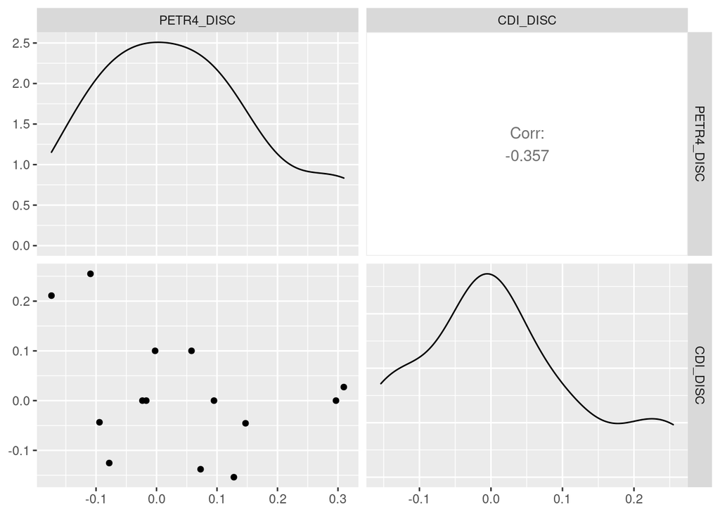

```r
ptr4.cdi = data.frame(PETR4_DISC = df.ret.disc[,"Petr4"],
                      CDI_DISC = cdi[,"cdi_disc"])
ggpairs(ptr4.cdi)
```

```r
correla = c(-1, cor(ptr4.cdi)[1,2], 1)

WA = seq(0, 1, 0.05)
WB = seq(1, 0, -0.05)

Risco = list()
for(i in 1:length(correla)){
  # risco(A,B) = sqrt(o²A * W²A + o²B * W²B + 2 * WA * WB * Corr(A,B) * oA * oB)
  Risco[[i]] = data.frame(x = sqrt(var(ptr4.cdi[,1]) * WA^2 + var(ptr4.cdi[,2]) * WB^2 + 2 * WA * WB * correla[i] * sd(ptr4.cdi[,1]) * sd(ptr4.cdi[,2])))
}
Risco = do.call(cbind, Risco)

Retorno = mean(ptr4.cdi[,1]) * WA + mean(ptr4.cdi[,2]) * WB

df2 = data.frame(WA, WB, Risco, Retorno)
names(df2)[3:5] <- c("Risco_Petr4_CDI-1", "Risco_Petr4_CDI-Real", "Risco_Petr4_CDI+1")
names(df2)
```

```
## [1] "WA"                   "WB"                   "Risco_Petr4_CDI-1"
## [4] "Risco_Petr4_CDI-Real" "Risco_Petr4_CDI+1"    "Retorno"
```

```r
wA = (var(ptr4.cdi[,2])-(correla[2]*sd(ptr4.cdi[,1])*sd(ptr4.cdi[,2])))/((var(ptr4.cdi[,1])+var(ptr4.cdi[,2]))-(2*correla[2]*sd(ptr4.cdi[,1])*sd(ptr4.cdi[,2])))
wB = 1-wA

risco = sqrt(var(ptr4.cdi[,1]) * wA^2 + var(ptr4.cdi[,2]) * wB^2 + 2 * wA * wB * correla[2] * sd(ptr4.cdi[,1]) * sd(ptr4.cdi[,2]))
retorno = mean(ptr4.cdi[,1]) * wA + mean(ptr4.cdi[,2]) * wB

names(df2)
```

```
## [1] "WA"                   "WB"                   "Risco_Petr4_CDI-1"
## [4] "Risco_Petr4_CDI-Real" "Risco_Petr4_CDI+1"    "Retorno"
```

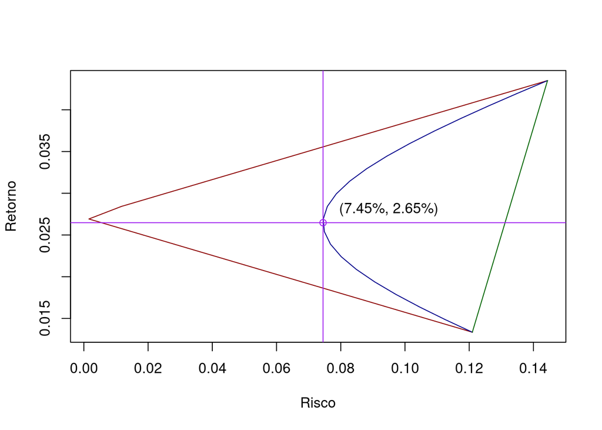

```r
plot(df2[,3], df2[,"Retorno"], col = "darkred", type = "l", xlab = "Risco", ylab = "Retorno")
lines(df2[,4], df2[,"Retorno"], col = "darkblue")
lines(df2[,5], df2[,"Retorno"], col = "darkgreen")
points(risco, retorno, col = "purple")
abline(v = risco, h = retorno, col = "purple")
text(x = 0.095, y = 0.028, paste0("(",round(risco,4)*100, "%, ", round(retorno,4)*100,"%)"))
```

### Questão 3)

### Um título A tem retorno esperado igual a 12,4% e seu retorno tem desvio padrão igual a 8,5%. O título B tem retorno esperado de 18,9% e desvio padrão de 15,7%a.a.. De posse dessa informação:

1. Qual deve ser o retorno esperado de uma carteira composta por 30% do título A e 70% do título B?
2. Sendo o coeficiente de correlação entre os dois retornos de A e B igual a 0,15, qual é o risco da carteira?

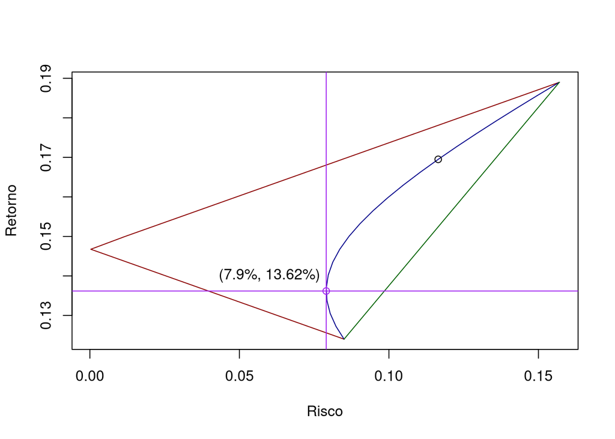

```r
df = data.frame(Titulo.A = c(0.124, 0.085), Titulo.B = c(0.189, 0.157),row.names = c("E[R]", "SD"))

correla = c(-1, .15, 1)

WA = seq(0, 1, 0.05)
WB = seq(1, 0, -0.05)

Risco = list()
for(i in 1:length(correla)){
  # risco(A,B) = sqrt(o²A * W²A + o²B * W²B + 2 * WA * WB * Corr(A,B) * oA * oB)
  Risco[[i]] = data.frame(x = sqrt(df[2,1]^2 * WA^2 + df[2,2]^2 * WB^2 + 2 * WA * WB * correla[i] * df[2,1] * df[2,2]))
}
Risco = do.call(cbind, Risco)

Retorno = df[1,1] * WA + df[1,2] * WB

df2 = data.frame(WA, WB, Risco, Retorno)
names(df2)[3:5] <- c("Risco-1", "Risco-Real", "Risco+1")

wA = (df[2,2]^2-(correla[2]*df[2,1]*df[2,2]))/((df[2,1]^2+df[2,2]^2)-(2*correla[2]*df[2,1]*df[2,2]))
wB = 1-wA

risco = sqrt(df[2,1]^2 * wA^2 + df[2,2]^2 * wB^2 + 2 * wA * wB * correla[2] * df[2,1] * df[2,2])
retorno = df[1,1] * wA + df[1,2] * wB

plot(df2[,3], df2[,"Retorno"], col = "darkred", type = "l", xlab = "Risco", ylab = "Retorno")
lines(df2[,4], df2[,"Retorno"], col = "darkblue")
lines(df2[,5], df2[,"Retorno"], col = "darkgreen")
points(risco, retorno, col = "purple")
points(sqrt(df[2,1]^2 * 0.3^2 + df[2,2]^2 * 0.7^2 + 2 * 0.3 * 0.7 * correla[2] * df[2,1] * df[2,2]),
       df[1,1] * 0.3 + df[1,2] * 0.7, col = "black")
abline(v = risco, h = retorno, col = "purple")
text(x = 0.06, y = 0.14, paste0("(",round(risco,4)*100, "%, ", round(retorno,4)*100,"%)"))
```

### Questão 4)

### Um título B tem Beta a 1,35 e o título C tem Beta de 0,851

1. Qual o Beta de uma carteira composta por 30% do título B e 70% do título C?
2. Por que a forma de cálculo do risco de uma carteira, medido pelo desvio padrão, é diferente do cálculo do risco de uma carteira medido pelo coeficiente Beta?

```r
beta.B = 1.35; beta.C = 0.851; wb = 0.3; wc = 0.7

beta.cart = beta.B*wb + beta.C*wc
cat("Valor de beta igual a", beta.cart)
```

```
## Valor de beta igual a 1.0007
```

Porque o ß mede o risco sistemático dos ativos, porém não mede o diversificável. No desvio-padrão está contido o risco total dos ativos.

### Questão 5)

### A ação A tem um retorno esperado de 16% e beta de 1,857. A ação B apresenta retorno esperado de 8,4% e beta de 0,820. O retorno da carteira de mercado ( KM ) é 10% e o retorno livre de risco ( K RF ) é 6,0%. Considerando os pesos de 35% para a ação A e 65% para a ação B.

1. Calcule o retorno esperado dessa carteira
2. Calcule o beta dessa carteira
3. Essa carteira tem mais ou menos risco sistemático do que um ativo médio representado pela carteira de mercado?
4. Qual é o prêmio de risco da carteira de mercado?
5. Qual o prêmio de risco da carteira formada pelas ações A e B?

```r
A.ret.esp = .16; beta.A = 1.857; B.ret.esp = .084; beta.B = .82; KM = .1; KRF = .06; WA = .35; WB = .65

ret.esp.cart = A.ret.esp*WA + B.ret.esp*WB
```

[output not shown]

### Questão 6)

### Suponha que um investidor possua 1000 ações da cia A e 3000 ações da Cia B. As ações da Cia A são cotadas a 180 u.m. por unidade, enquanto as ações da Cia B são negociadas a 90 u.m.. O retorno esperado da Cia A é igual a 15%, enquanto que o da B é de 20%. O desvio padrão do retorno de A é igual a 8%, ao passo que o da B é igual a 20%. O coeficiente de correlação entre os retornos das duas ações é 0,38.

1. Calcule o retorno esperado e o desvio padrão da carteira do investidor;
2. Admita que o investidor venda hoje 2000 ações da Cia B. Calcule o retorno e o desvio padrão de sua nova carteira.

```r
Ativo.A = 1000; preco.A = 180; ret.esp.A = 0.15; sd.A = 0.08
Ativo.B = 3000; preco.B = 90; ret.esp.B = 0.2; sd.B = 0.2;
corrAB = 0.38
montante = Ativo.A*preco.A + Ativo.B*preco.B
wa = Ativo.A*preco.A/montante
wb = Ativo.B*preco.B/montante

# Alternativa a)
ret.esp = round(wa * ret.esp.A + wb * ret.esp.B,4)
sd.cart = round(sqrt(sd.A^2 * wa^2 + sd.B^2 * wb^2 + 2 * wa * wb * corrAB * sd.A * sd.B),4)

cat("Retorno esperado da carteira: ", ret.esp,"\n\n",
    "Desvio-padrão da carteira: ", sd.cart, sep = "")
```

```
## Retorno esperado da carteira: 0.18
##
## Desvio-padrão da carteira: 0.1354
```

```r
# Alternativa b)
Ativo.B = 1000
montante = Ativo.A*preco.A + Ativo.B*preco.B
wa = Ativo.A*preco.A/montante
wb = Ativo.B*preco.B/montante

ret.esp = round(wa * ret.esp.A + wb * ret.esp.B,4)
sd.cart = round(sqrt(sd.A^2 * wa^2 + sd.B^2 * wb^2 + 2 * wa * wb * corrAB * sd.A * sd.B),4)

cat("Novo retorno esperado da carteira: ", ret.esp,"\n\n",
    "Novo desvio-padrão da carteira: ", sd.cart, sep = "")
```

```
## Novo retorno esperado da carteira: 0.1667
##
## Novo desvio-padrão da carteira: 0.1
```

### Questão 7)

### Você tem uma carteira de $ 2 milhões que consiste em $ 100.000 de investimentos em cada um dos 20 diferentes ativos. A carteira tem um beta igual a 1,1. Você está considerando a venda de $ 100.000 de uma ação cujo beta é igual a 0,9, a fim de utilizar esses recursos para comprar outra ação que tenha um beta igual a 1,4. Qual será o novo beta de sua carteira após essa transação?

```r
p = 1/20; ß.cart = 1.1; beta1 = .9; beta2 = 1.4

# 1.1 = 1/20 * (.9+1.4+x)
# 1.1 = 1/20*.9 + 1/20*1.4 + 1/20*x
x = (1.1 - 1/20*.9 - 1/20*1.4)*20

ß.cart2 = 2/20*1.4 + 1/20*x

cat("O novo beta da carteira é de:", ß.cart2)
```

```
## O novo beta da carteira é de: 1.125
```

### Questão 8

### Sabe-se que a taxa livre de risco de é de 5% a.a. o retorno da carteira de mercado é 15% a.a. Os betas de três ativos (A, B e C) são:

```r
df = data.frame(Ativo_A = 0.7,
                Ativo_B = 1,
                Ativo_C = 1.5,
                row.names = "Beta")
df
```

```
##      Ativo_A Ativo_B Ativo_C
## Beta     0.7       1     1.5
```

1. Determine a taxa de retorno requerida para os Ativos A, B e C com base no modelo CAPM;

```r
tlr = 0.05; kcm = 0.15

ksA = tlr + (kcm - tlr)*df[1,1]
ksB = tlr + (kcm - tlr)*df[1,2]
ksC = tlr + (kcm - tlr)*df[1,3]

cat("Retorno requerido para A: ", ksA, "\n\n",
    "Retorno requerido para B: ", ksB, "\n\n",
    "Retorno requerido para C: ", ksC, sep = "")
```

```
## Retorno requerido para A: 0.12
##
## Retorno requerido para B: 0.15
##
## Retorno requerido para C: 0.2
```

2. Refaça seus cálculos, admitindo que a carteira de mercado tivesse um retorno de 12%

```r
tlr = 0.05; kcm = 0.12

ksA = tlr + (kcm - tlr)*df[1,1]
ksB = tlr + (kcm - tlr)*df[1,2]
ksC = tlr + (kcm - tlr)*df[1,3]

cat("Retorno requerido para A: ", ksA, "\n\n",
    "Retorno requerido para B: ", ksB, "\n\n",
    "Retorno requerido para C: ", ksC, sep = "")
```

```
## Retorno requerido para A: 0.099
##
## Retorno requerido para B: 0.12
##
## Retorno requerido para C: 0.155
```

3. Determine o retorno esperado da carteira “C” composta por: 20% de A; 40% de B e 40% de C

```r
ret.esp.cart = 0.2 * df[1,1] + 0.4 * df[1,2] + 0.4 * df[1,3]

cat("Retorno esperado para 20% de A, 40% de B e 40% de C:", ret.esp.cart)
```

```
## Retorno esperado para 20% de A, 40% de B e 40% de C: 1.14
```

4. Determine o retorno esperado da carteira “D” composta por: 80% de A; 10% de B e 10% de C

```r
ret.esp.cart = 0.8 * df[1,1] + 0.1 * df[1,2] + 0.1 * df[1,3]

cat("Retorno esperado para 80% de A, 10% de B e 10% de C:", ret.esp.cart)
```

```
## Retorno esperado para 80% de A, 10% de B e 10% de C: 0.81
```

5. Intuitivamente qual carteira tem mais risco (Carteira de C ou D)?

### Questão 9)

### Taxa requerida de retorno: Pressuponha que a taxa livre de risco seja de 6% e que o retorno esperado do mercado seja de 13%. Qual é a taxa requerida de retorno de uma ação que tem beta de 0,7?

```r
tlr = 0.06; ret.esp.merc = 0.13

ks = tlr + 0.7 * (ret.esp.merc - tlr)

cat("Taxa requerida de retorno igual a:", ks)
```

```
## Taxa requerida de retorno igual a: 0.109
```

### Questão 10)

### Uma ação tem beta de 1,8. Um analista de títulos especializado nessa ação espera que seu retorno futuro seja de 18%. Imagine que a taxa livre de risco seja de 5% e que o prêmio por risco de mercado seja igual a 8%. Este analista é pessimista ou otimista com relação a essa ação, em comparação com as expectativas de mercado?

```r
beta = 1.8; ret.esp = 0.18; tlr = 0.05; pprm = 0.08

ks = tlr + beta * (ret.esp - tlr) + pprm

cat("Taxa requerida de retorno igual a:", ks,"\n",
    "Dessa forma, como o retorno requerido é maior que a esperança de retorno, o analista é otimista quanto essa ação")
```

```
## Taxa requerida de retorno igual a: 0.364
##  Dessa forma, como o retorno requerido é maior que a esperança de retorno, o analista é otimista quanto essa ação
```